# Tugas Pertemuan 4

Muhammad Rafif Danuja

2025-09-25

# 1 MA(2)

## 1.1 Pembangkitan Data

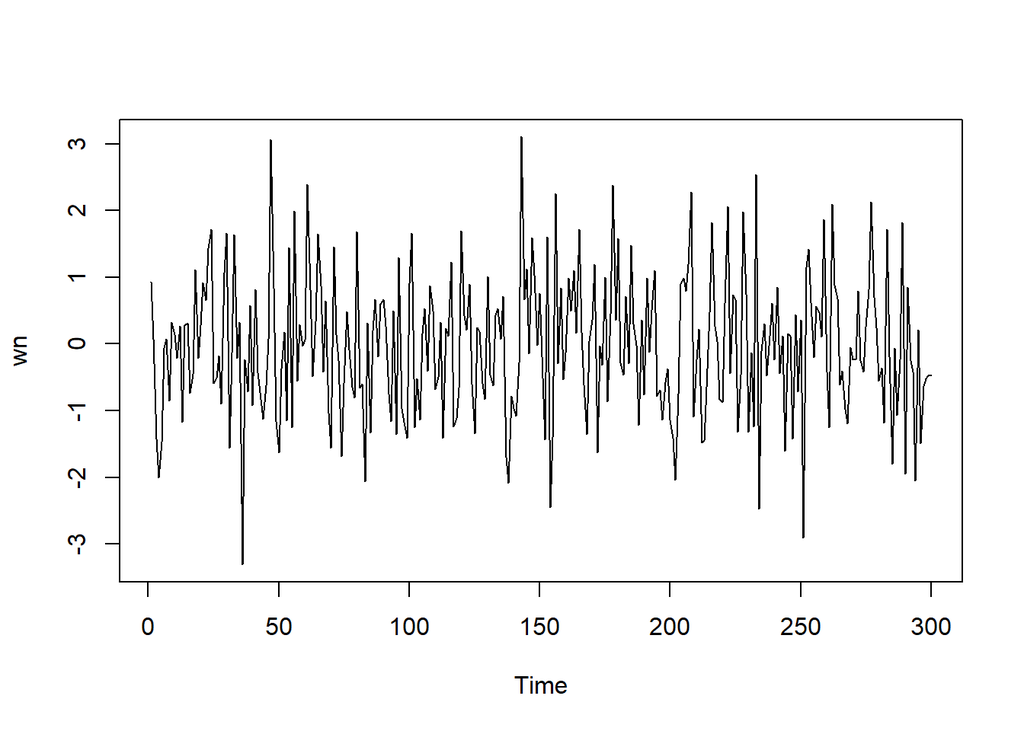

```r
set.seed(1015)
wn <- rnorm(300)
n <- 300
ts.plot(wn)
```

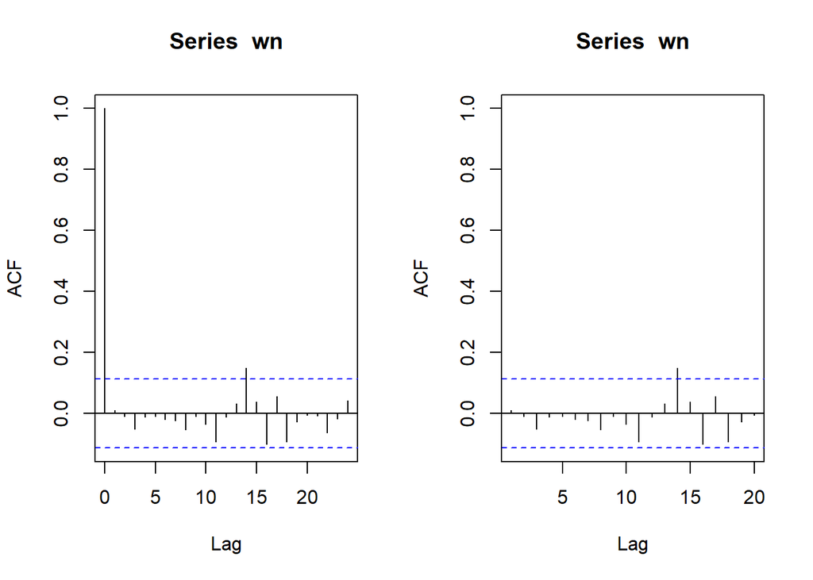

```r
par(mfrow = c(1, 2))
acf(wn)
acf(wn, xlim = c(1, 20))
```

```r
set.seed(1015)
ma <- wn[1:2]
```

```r
for(i in 3:n){
  ma[i] <- wn[i] + 0.4 * wn[i - 1] + 0.6 * wn[i - 2]
}

ma
```

```
##   [1]  0.923537790  0.078371749 -0.831428231 -2.522817523 -3.114263383
##   [6] -1.848048177 -0.823856433 -0.856792741  0.025853451 -0.237211732
##  [11]  0.033653959  0.267224997 -1.197946764 -0.032857720 -0.286415218
##  [16] -0.447573258 -0.557322881  0.485840139 -0.038583341  0.856647554
##  [21]  0.899529265  1.187344239  2.242103868  2.676338605  0.959257009
##  [26]  0.285434805 -0.731434487 -1.272855694  0.596136525  1.545233943
##  [31] -0.259590618  0.239757101  0.642018643  0.363488695  1.214676347
##  [36] -3.305618987 -1.366503761 -2.790310956  0.154549479 -1.116487756
##  [41]  0.794805761 -0.654790824 -0.515094188 -1.717061458 -1.570018730
##  [46] -0.854726038  2.714365463  2.098930407  1.010467971 -1.595341733
##  [51] -1.725514318 -0.959793472 -1.301551846  1.086755396 -1.363943710
##  [56]  2.351733537 -0.512406758  1.264852358 -0.246488590  0.221782756
##  [61]  2.396900161  1.802427633  1.273250314  0.630740192  1.489200731
##  [66]  1.729313650  0.914585894  1.001786955 -1.022692450 -1.585942242
##  [71]  0.207409028 -0.211133963  0.681271489 -1.699290904 -1.415273116
```

[output cut: 45 more lines]

```r
set.seed(1015)
ma2 <- arima.sim(
  list(order = c(0,0,2), ma = c(0.4, 0.6)),
  n = 300
)
ma2
```

```
## Time Series:
## Start = 1
## End = 300
## Frequency = 1
##   [1] -0.831428231 -2.522817523 -3.114263383 -1.848048177 -0.823856433
##   [6] -0.856792741  0.025853451 -0.237211732  0.033653959  0.267224997
##  [11] -1.197946764 -0.032857720 -0.286415218 -0.447573258 -0.557322881
##  [16]  0.485840139 -0.038583341  0.856647554  0.899529265  1.187344239
##  [21]  2.242103868  2.676338605  0.959257009  0.285434805 -0.731434487
##  [26] -1.272855694  0.596136525  1.545233943 -0.259590618  0.239757101
##  [31]  0.642018643  0.363488695  1.214676347 -3.305618987 -1.366503761
##  [36] -2.790310956  0.154549479 -1.116487756  0.794805761 -0.654790824
##  [41] -0.515094188 -1.717061458 -1.570018730 -0.854726038  2.714365463
##  [46]  2.098930407  1.010467971 -1.595341733 -1.725514318 -0.959793472
##  [51] -1.301551846  1.086755396 -1.363943710  2.351733537 -0.512406758
```

[output cut: 49 more lines]

## 1.2 Plot Time Series

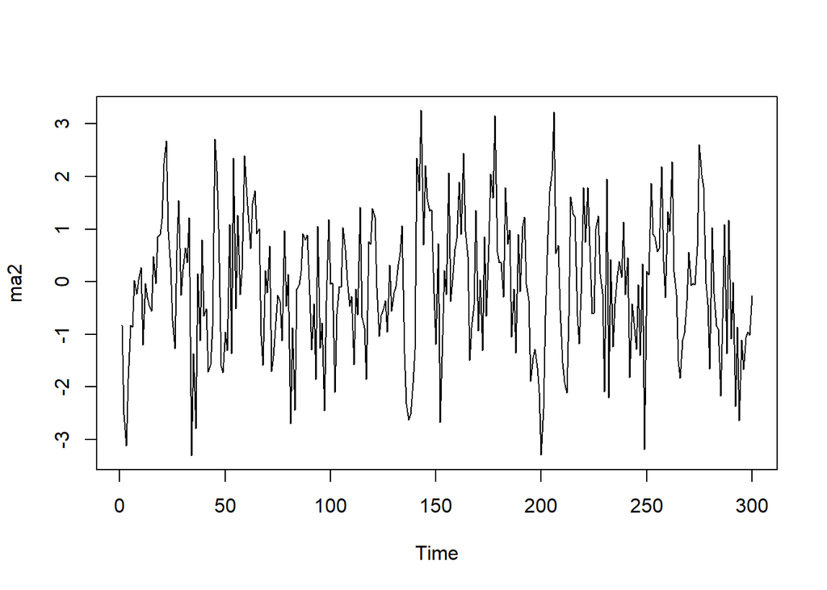

```r
ts.plot(ma2)
```

Berdasarkan plot time series, terlihat bahwa data MA(2) yang dibangkitkan bersifat stasioner dalam rataan, ditunjukkan oleh nilai rata-rata yang relatif konstan dari waktu ke waktu tanpa adanya tren naik atau turun yang jelas.

## 1.3 Plot ACF

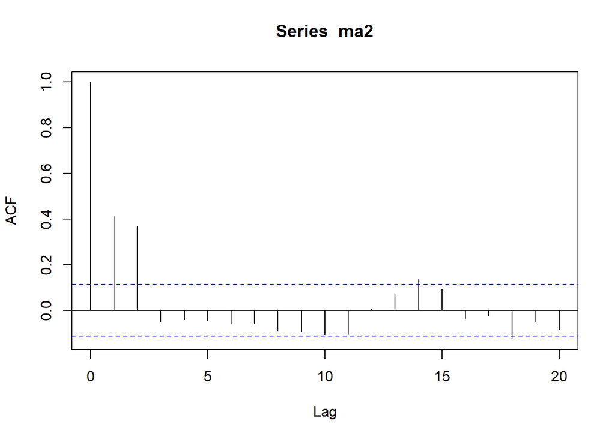

```r
acf(ma2,lag.max = 20)
```

Berdasarkan plot ACF tersebut, terlihat bahwa nilai autokorelasi mengalami cut-off setelah lag ke-2, yaitu hanya signifikan pada lag 1 dan lag 2, sedangkan untuk lag-lag berikutnya nilainya mendekati nol dan tidak lagi signifikan.

## 1.4 Plot PACF

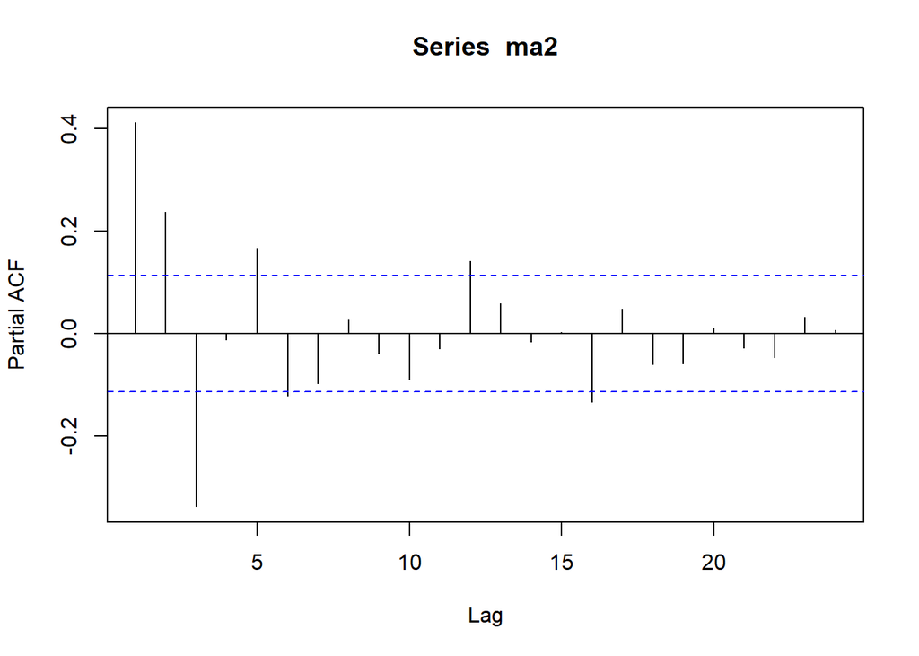

```r
pacf(ma2)
```

Berdasarkan plot PACF tersebut, terlihat bahwa nilai PACF tidak terputus secara jelas, melainkan menunjukkan pola tails off yang secara perlahan mengecil seiring bertambahnya lag. Selain itu, bentuk plot PACF memperlihatkan pola menyerupai gelombang sinus yang berosilasi di sekitar nol. Pola ini merupakan karakteristik dari proses Moving Average orde 2.

## 1.5 Plot EACF

```r
TSA::eacf(ma2)
```

```
## AR/MA
##   0 1 2 3 4 5 6 7 8 9 10 11 12 13
## 0 x x o o o o o o o o o  o  o  x
## 1 x x x o o o o o o o o  o  o  o
## 2 x x x o o o o o o o o  o  o  o
## 3 o x x x o o o o o o o  o  o  o
## 4 o x x x x o o o o o o  o  o  o
## 5 x x x x x x o o o o o  o  o  o
## 6 x x x x x o o o o o o  o  o  o
## 7 x x x x o o o o o o o  o  o  o
```

Berdasarkan pola segitiga nol pada plot EACF, terlihat bahwa segitiga nol berada pada ordo AR(0) dan ordo MA(2)

## 1.6 Scatterplot Antar Lag

### 1.6.1 Korelasi antara Yt dengan Yt−1

```r
yt_ma <- ma2[-1]
yt_ma
```

```
##   [1] -2.522817523 -3.114263383 -1.848048177 -0.823856433 -0.856792741
##   [6]  0.025853451 -0.237211732  0.033653959  0.267224997 -1.197946764
##  [11] -0.032857720 -0.286415218 -0.447573258 -0.557322881  0.485840139
##  [16] -0.038583341  0.856647554  0.899529265  1.187344239  2.242103868
##  [21]  2.676338605  0.959257009  0.285434805 -0.731434487 -1.272855694
##  [26]  0.596136525  1.545233943 -0.259590618  0.239757101  0.642018643
##  [31]  0.363488695  1.214676347 -3.305618987 -1.366503761 -2.790310956
##  [36]  0.154549479 -1.116487756  0.794805761 -0.654790824 -0.515094188
##  [41] -1.717061458 -1.570018730 -0.854726038  2.714365463  2.098930407
##  [46]  1.010467971 -1.595341733 -1.725514318 -0.959793472 -1.301551846
##  [51]  1.086755396 -1.363943710  2.351733537 -0.512406758  1.264852358
##  [56] -0.246488590  0.221782756  2.396900161  1.802427633  1.273250314
##  [61]  0.630740192  1.489200731  1.729313650  0.914585894  1.001786955
##  [66] -1.022692450 -1.585942242  0.207409028 -0.211133963  0.681271489
##  [71] -1.699290904 -1.415273116 -0.762870600 -0.251983100 -0.387840479
```

[output cut: 45 more lines]

```r
yt_1_ma <- ma2[-300]
yt_1_ma
```

```
##   [1] -0.831428231 -2.522817523 -3.114263383 -1.848048177 -0.823856433
##   [6] -0.856792741  0.025853451 -0.237211732  0.033653959  0.267224997
##  [11] -1.197946764 -0.032857720 -0.286415218 -0.447573258 -0.557322881
##  [16]  0.485840139 -0.038583341  0.856647554  0.899529265  1.187344239
##  [21]  2.242103868  2.676338605  0.959257009  0.285434805 -0.731434487
##  [26] -1.272855694  0.596136525  1.545233943 -0.259590618  0.239757101
##  [31]  0.642018643  0.363488695  1.214676347 -3.305618987 -1.366503761
##  [36] -2.790310956  0.154549479 -1.116487756  0.794805761 -0.654790824
##  [41] -0.515094188 -1.717061458 -1.570018730 -0.854726038  2.714365463
##  [46]  2.098930407  1.010467971 -1.595341733 -1.725514318 -0.959793472
##  [51] -1.301551846  1.086755396 -1.363943710  2.351733537 -0.512406758
##  [56]  1.264852358 -0.246488590  0.221782756  2.396900161  1.802427633
##  [61]  1.273250314  0.630740192  1.489200731  1.729313650  0.914585894
##  [66]  1.001786955 -1.022692450 -1.585942242  0.207409028 -0.211133963
##  [71]  0.681271489 -1.699290904 -1.415273116 -0.762870600 -0.251983100
```

[output cut: 45 more lines]

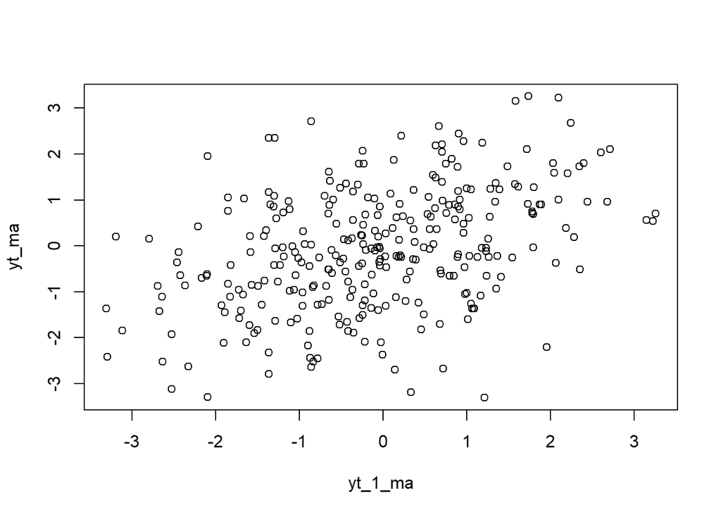

```r
plot(y=yt_ma,x=yt_1_ma)
```

```r
cor(yt_ma,yt_1_ma)
```

```
## [1] 0.4119891
```

Teoritis :

$$\rho_1 = \frac{\gamma_1}{\gamma_0} = \frac{\theta_1 + \theta_1
\theta_2}{1 + \theta_1^2 + \theta_2^2} =
\frac{0.4+(0.4)(0.6)}{1+0.4^2+0.6^2}=0.421$$

### 1.6.2 Korelasi antara Yt dengan Yt−2

```r
yt_ma2 <- ma2[-c(1,2)]
yt_ma2
```

```
##   [1] -3.114263383 -1.848048177 -0.823856433 -0.856792741  0.025853451
##   [6] -0.237211732  0.033653959  0.267224997 -1.197946764 -0.032857720
##  [11] -0.286415218 -0.447573258 -0.557322881  0.485840139 -0.038583341
##  [16]  0.856647554  0.899529265  1.187344239  2.242103868  2.676338605
##  [21]  0.959257009  0.285434805 -0.731434487 -1.272855694  0.596136525
##  [26]  1.545233943 -0.259590618  0.239757101  0.642018643  0.363488695
##  [31]  1.214676347 -3.305618987 -1.366503761 -2.790310956  0.154549479
##  [36] -1.116487756  0.794805761 -0.654790824 -0.515094188 -1.717061458
##  [41] -1.570018730 -0.854726038  2.714365463  2.098930407  1.010467971
##  [46] -1.595341733 -1.725514318 -0.959793472 -1.301551846  1.086755396
##  [51] -1.363943710  2.351733537 -0.512406758  1.264852358 -0.246488590
##  [56]  0.221782756  2.396900161  1.802427633  1.273250314  0.630740192
##  [61]  1.489200731  1.729313650  0.914585894  1.001786955 -1.022692450
##  [66] -1.585942242  0.207409028 -0.211133963  0.681271489 -1.699290904
##  [71] -1.415273116 -0.762870600 -0.251983100 -0.387840479 -1.123388533
```

[output cut: 45 more lines]

```r
yt_2_ma <- ma2[-c(299,300)]
yt_2_ma
```

```
##   [1] -0.831428231 -2.522817523 -3.114263383 -1.848048177 -0.823856433
##   [6] -0.856792741  0.025853451 -0.237211732  0.033653959  0.267224997
##  [11] -1.197946764 -0.032857720 -0.286415218 -0.447573258 -0.557322881
##  [16]  0.485840139 -0.038583341  0.856647554  0.899529265  1.187344239
##  [21]  2.242103868  2.676338605  0.959257009  0.285434805 -0.731434487
##  [26] -1.272855694  0.596136525  1.545233943 -0.259590618  0.239757101
##  [31]  0.642018643  0.363488695  1.214676347 -3.305618987 -1.366503761
##  [36] -2.790310956  0.154549479 -1.116487756  0.794805761 -0.654790824
##  [41] -0.515094188 -1.717061458 -1.570018730 -0.854726038  2.714365463
##  [46]  2.098930407  1.010467971 -1.595341733 -1.725514318 -0.959793472
##  [51] -1.301551846  1.086755396 -1.363943710  2.351733537 -0.512406758
##  [56]  1.264852358 -0.246488590  0.221782756  2.396900161  1.802427633
##  [61]  1.273250314  0.630740192  1.489200731  1.729313650  0.914585894
##  [66]  1.001786955 -1.022692450 -1.585942242  0.207409028 -0.211133963
##  [71]  0.681271489 -1.699290904 -1.415273116 -0.762870600 -0.251983100
```

[output cut: 45 more lines]

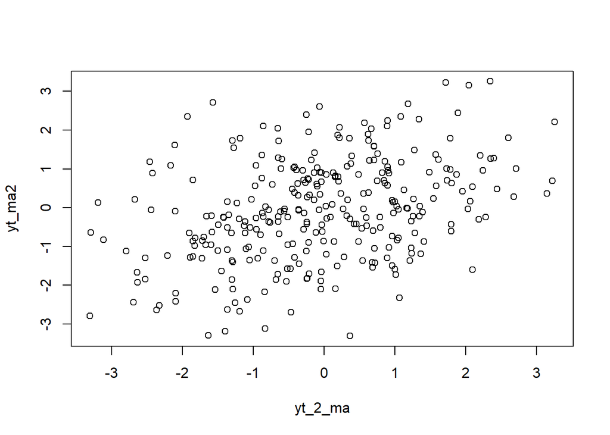

```r
plot(y=yt_ma2,x=yt_2_ma)
```

```r
cor(yt_ma2,yt_2_ma)
```

```
## [1] 0.3699548
```

Teoritis :

$$\rho_2 = \frac{\gamma_2}{\gamma_0} =
\frac{\theta_2}{1 + \theta_1^2 + \theta_2^2} =
\frac{0.6}{1+0.4^2+0.6^2}=0.395$$

### 1.6.3 Korelasi antara Yt dengan Yt-3

```r
yt <- ma2[-c(1,2,3)]
yt
```

```
##   [1] -1.848048177 -0.823856433 -0.856792741  0.025853451 -0.237211732
##   [6]  0.033653959  0.267224997 -1.197946764 -0.032857720 -0.286415218
##  [11] -0.447573258 -0.557322881  0.485840139 -0.038583341  0.856647554
##  [16]  0.899529265  1.187344239  2.242103868  2.676338605  0.959257009
##  [21]  0.285434805 -0.731434487 -1.272855694  0.596136525  1.545233943
##  [26] -0.259590618  0.239757101  0.642018643  0.363488695  1.214676347
##  [31] -3.305618987 -1.366503761 -2.790310956  0.154549479 -1.116487756
##  [36]  0.794805761 -0.654790824 -0.515094188 -1.717061458 -1.570018730
##  [41] -0.854726038  2.714365463  2.098930407  1.010467971 -1.595341733
##  [46] -1.725514318 -0.959793472 -1.301551846  1.086755396 -1.363943710
##  [51]  2.351733537 -0.512406758  1.264852358 -0.246488590  0.221782756
##  [56]  2.396900161  1.802427633  1.273250314  0.630740192  1.489200731
##  [61]  1.729313650  0.914585894  1.001786955 -1.022692450 -1.585942242
##  [66]  0.207409028 -0.211133963  0.681271489 -1.699290904 -1.415273116
##  [71] -0.762870600 -0.251983100 -0.387840479 -1.123388533  0.973858557
```

[output cut: 45 more lines]

```r
yt_3ma <- ma2[-c(298,299,300)]
yt_3ma
```

```
##   [1] -0.831428231 -2.522817523 -3.114263383 -1.848048177 -0.823856433
##   [6] -0.856792741  0.025853451 -0.237211732  0.033653959  0.267224997
##  [11] -1.197946764 -0.032857720 -0.286415218 -0.447573258 -0.557322881
##  [16]  0.485840139 -0.038583341  0.856647554  0.899529265  1.187344239
##  [21]  2.242103868  2.676338605  0.959257009  0.285434805 -0.731434487
##  [26] -1.272855694  0.596136525  1.545233943 -0.259590618  0.239757101
##  [31]  0.642018643  0.363488695  1.214676347 -3.305618987 -1.366503761
##  [36] -2.790310956  0.154549479 -1.116487756  0.794805761 -0.654790824
##  [41] -0.515094188 -1.717061458 -1.570018730 -0.854726038  2.714365463
##  [46]  2.098930407  1.010467971 -1.595341733 -1.725514318 -0.959793472
##  [51] -1.301551846  1.086755396 -1.363943710  2.351733537 -0.512406758
##  [56]  1.264852358 -0.246488590  0.221782756  2.396900161  1.802427633
##  [61]  1.273250314  0.630740192  1.489200731  1.729313650  0.914585894
##  [66]  1.001786955 -1.022692450 -1.585942242  0.207409028 -0.211133963
##  [71]  0.681271489 -1.699290904 -1.415273116 -0.762870600 -0.251983100
```

[output cut: 45 more lines]

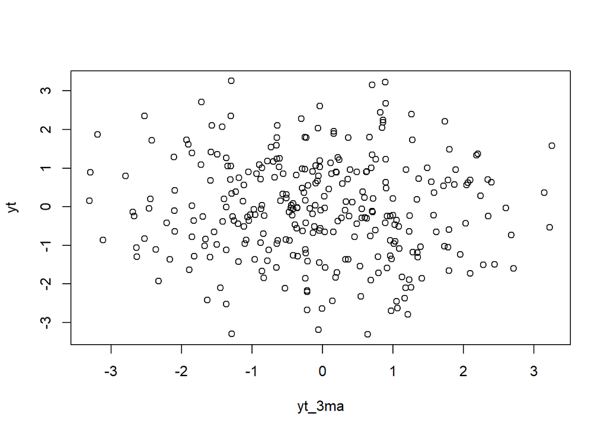

```r
plot(y=yt,x=yt_3ma)
```

```r
cor(yt, yt_3ma)
```

```
## [1] -0.05245215
```

Teoritis :

$$\rho_3 = 0$$

# 2 AR(2)

## 2.1 Pembangkitan Data

```r
set.seed(1015)
```

```r
n<-length(wn)
n
```

```
## [1] 300
```

```r
ar2 <- numeric(n)

for (i in 3:n) {
  ar2[i] <- wn[i] + 0.5 * ar2[i-1] + 0.2 * ar2[i-2]
}

ar2
```

```
##   [1]  0.000000000  0.000000000 -1.416899605 -2.711530533 -3.102036515
##   [6] -2.154367571 -1.619295442 -2.092006311 -1.050392151 -0.797706061
##  [11] -0.825316068 -0.305955172 -1.492654429 -0.530276961 -0.256212922
##  [16] -0.971062462 -0.983810320  0.420677453 -0.199502817  0.262186365
##  [21]  1.007448659  1.210322056  2.237336822  3.072300731  1.399835939
##  [26]  0.806384892  0.505191511 -0.482999777  0.921204817  2.022693341
##  [31] -0.364479181  0.090868371  1.603169364  0.609853069  0.945820260
##  [36] -2.712899012 -1.402833224 -1.955420409 -0.677829111 -1.651811092
##  [41] -0.146209268 -0.831275044 -1.278007547 -1.932384057 -1.841085255
##  [46] -1.237753625  2.071140304  1.622096679  0.067172970 -1.274540891
##  [51] -1.001469427 -0.584854906 -1.636008234  0.506622265 -1.328501033
##  [56]  1.425693264 -0.107941752  0.524883810  0.209931457  0.267864466
##  [61]  2.568203154  2.148435066  1.101433462  1.319257460  2.525429488
##  [66]  2.394362030  1.282426050  1.769131255  0.110644576 -1.154058693
##  [71]  0.896035246  0.363621990  0.113161685 -1.558692783 -1.348074146
```

[output cut: 45 more lines]

```r
ar <- arima.sim(
  list(order = c(2,0,0), ar = c(0.5, 0.2)),
  n = 300
)
ar
```

```
## Time Series:
## Start = 1
## End = 300
## Frequency = 1
##   [1]  0.807249213  0.505850424 -0.482497456  0.921587760  2.022985277
##   [6] -0.364256625  0.091038037  1.603298708  0.609951674  0.945895432
##  [11] -2.712841705 -1.402789536 -1.955387104 -0.677803721 -1.651791736
##  [16] -0.146194512 -0.831263794 -1.277998971 -1.932377519 -1.841080271
##  [21] -1.237749826  2.071143201  1.622098887  0.067174653 -1.274539608
##  [26] -1.001468448 -0.584854160 -1.636007665  0.506622698 -1.328500702
##  [31]  1.425693515 -0.107941560  0.524883956  0.209931569  0.267864551
##  [36]  2.568203219  2.148435116  1.101433500  1.319257488  2.525429510
##  [41]  2.394362047  1.282426063  1.769131265  0.110644583 -1.154058688
##  [46]  0.896035250  0.363621993  0.113161687 -1.558692781 -1.348074144
##  [51] -0.499303378 -0.611022463 -1.048393358 -1.457527557  0.745679531
```

[output cut: 49 more lines]

## 2.2 Plot Time Series

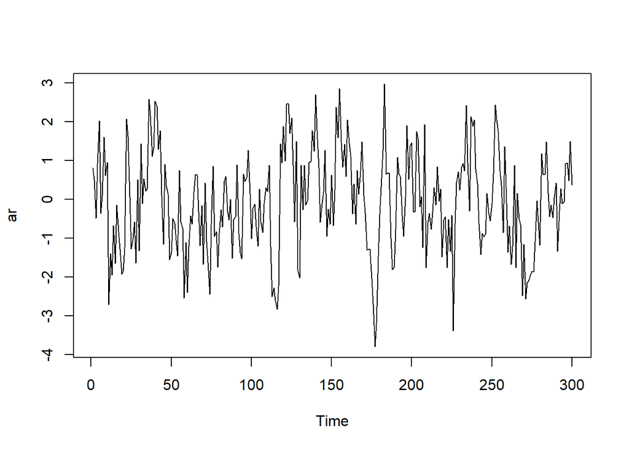

```r
ts.plot(ar)
```

Berdasarkan plot time series di atas, terlihat bahwa data hasil bangkitan dari proses AR(2) berfluktuasi di sekitar rata-rata nol tanpa menunjukkan adanya tren naik maupun tren turun yang jelas dari waktu ke waktu. Hal ini menunjukkan bahwa data tersebut stasioner.

## 2.3 Plot ACF

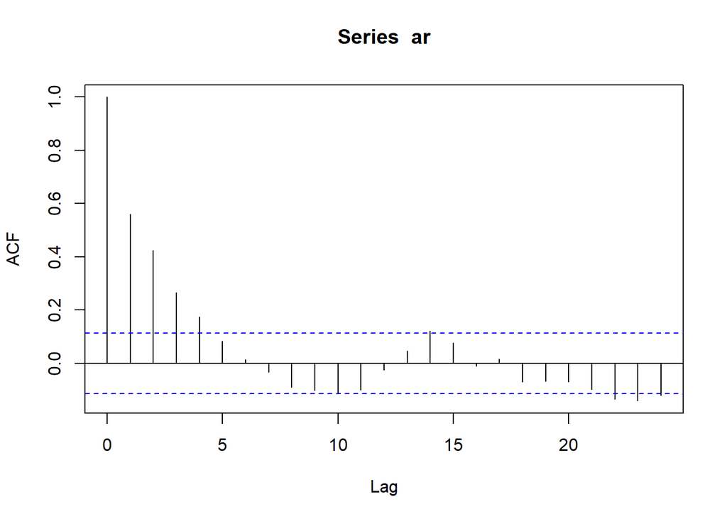

```r
acf(ar)
```

Terlihat bahwa nilai autokorelasi menurun secara bertahap (tails off) dan tidak mengalami cut-off pada lag tertentu. Pola ini sesuai dengan karakteristik proses AR, di mana ACF mengecil perlahan seiring bertambahnya lag.

## 2.4 Plot PACF

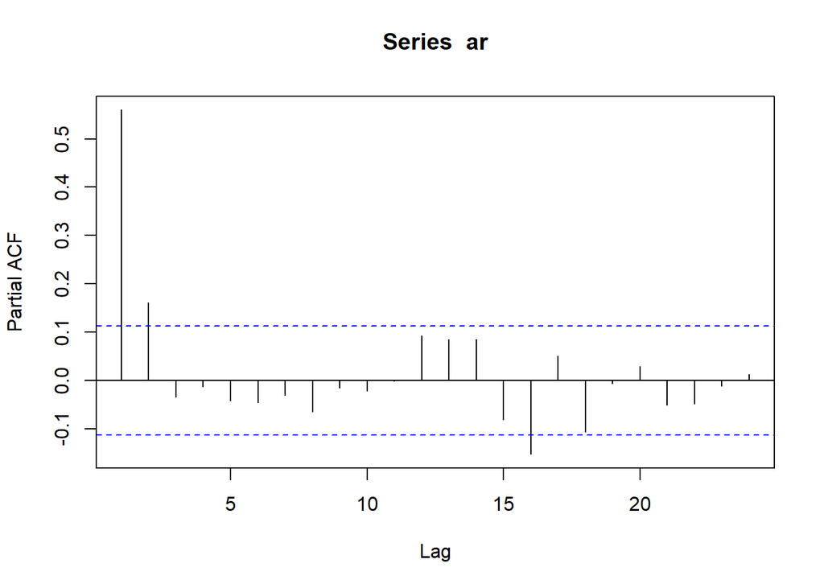

```r
pacf(ar)
```

Nilai partial autocorrelation menunjukkan cut-off yang jelas pada lag ke-2, sementara lag setelahnya tidak signifikan. Pola ini merupakan ciri khas dari proses AR(2), di mana PACF terputus pada lag sesuai dengan orde model.

## 2.5 Plot EACF

```r
TSA::eacf(ar)
```

```
## AR/MA
##   0 1 2 3 4 5 6 7 8 9 10 11 12 13
## 0 x x x x o o o o o o o  o  o  x
## 1 x o o o o o o o o o o  o  o  x
## 2 x o o o o o o o o o o  o  o  o
## 3 x o o o o o o o o o o  o  o  o
## 4 x x o o o o o o o o o  o  o  o
## 5 x x x o o o o o o o o  o  o  o
## 6 x x o x o o o o o o o  o  o  o
## 7 x x o x o o o o o o o  o  o  o
```

Tabel pemilihan orde ARMA menunjukkan bahwa kombinasi AR(2) dengan berbagai orde MA (q ≥ 1) umumnya menghasilkan model yang layak (ditandai dengan simbol o). Hal ini sejalan dengan analisis sebelumnya bahwa proses data dapat direpresentasikan dengan komponen autoregresif orde 2. Pola ini memperkuat indikasi bahwa AR(2) merupakan struktur utama yang relevan dalam model

## 2.6 Scatterplot Antar Lag

### 2.6.1 Korelasi antara Yt dengan Yt−1

```r
yt_ar <- ar[-1]
yt_ar
```

```
##   [1]  0.505850424 -0.482497456  0.921587760  2.022985277 -0.364256625
##   [6]  0.091038037  1.603298708  0.609951674  0.945895432 -2.712841705
##  [11] -1.402789536 -1.955387104 -0.677803721 -1.651791736 -0.146194512
##  [16] -0.831263794 -1.277998971 -1.932377519 -1.841080271 -1.237749826
##  [21]  2.071143201  1.622098887  0.067174653 -1.274539608 -1.001468448
##  [26] -0.584854160 -1.636007665  0.506622698 -1.328500702  1.425693515
##  [31] -0.107941560  0.524883956  0.209931569  0.267864551  2.568203219
##  [36]  2.148435116  1.101433500  1.319257488  2.525429510  2.394362047
##  [41]  1.282426063  1.769131265  0.110644583 -1.154058688  0.896035250
##  [46]  0.363621993  0.113161687 -1.558692781 -1.348074144 -0.499303378
##  [51] -0.611022463 -1.048393358 -1.457527557  0.745679531 -0.574420301
##  [56] -0.741965495 -2.543147652 -1.106951587 -2.395378577 -1.216590203
##  [61] -0.424355478 -0.643614824  0.187415972  0.632517557  0.621147254
##  [66] -0.315677472 -1.191990704 -0.161930616 -1.673499354  0.424584000
##  [71] -1.082632771 -1.627821509 -2.441883602 -0.639076115  0.853620796
```

[output cut: 45 more lines]

```r
yt_1_ar <- ar[-300]
yt_1_ar
```

```
##   [1]  0.807249213  0.505850424 -0.482497456  0.921587760  2.022985277
##   [6] -0.364256625  0.091038037  1.603298708  0.609951674  0.945895432
##  [11] -2.712841705 -1.402789536 -1.955387104 -0.677803721 -1.651791736
##  [16] -0.146194512 -0.831263794 -1.277998971 -1.932377519 -1.841080271
##  [21] -1.237749826  2.071143201  1.622098887  0.067174653 -1.274539608
##  [26] -1.001468448 -0.584854160 -1.636007665  0.506622698 -1.328500702
##  [31]  1.425693515 -0.107941560  0.524883956  0.209931569  0.267864551
##  [36]  2.568203219  2.148435116  1.101433500  1.319257488  2.525429510
##  [41]  2.394362047  1.282426063  1.769131265  0.110644583 -1.154058688
##  [46]  0.896035250  0.363621993  0.113161687 -1.558692781 -1.348074144
##  [51] -0.499303378 -0.611022463 -1.048393358 -1.457527557  0.745679531
##  [56] -0.574420301 -0.741965495 -2.543147652 -1.106951587 -2.395378577
##  [61] -1.216590203 -0.424355478 -0.643614824  0.187415972  0.632517557
##  [66]  0.621147254 -0.315677472 -1.191990704 -0.161930616 -1.673499354
##  [71]  0.424584000 -1.082632771 -1.627821509 -2.441883602 -0.639076115
```

[output cut: 45 more lines]

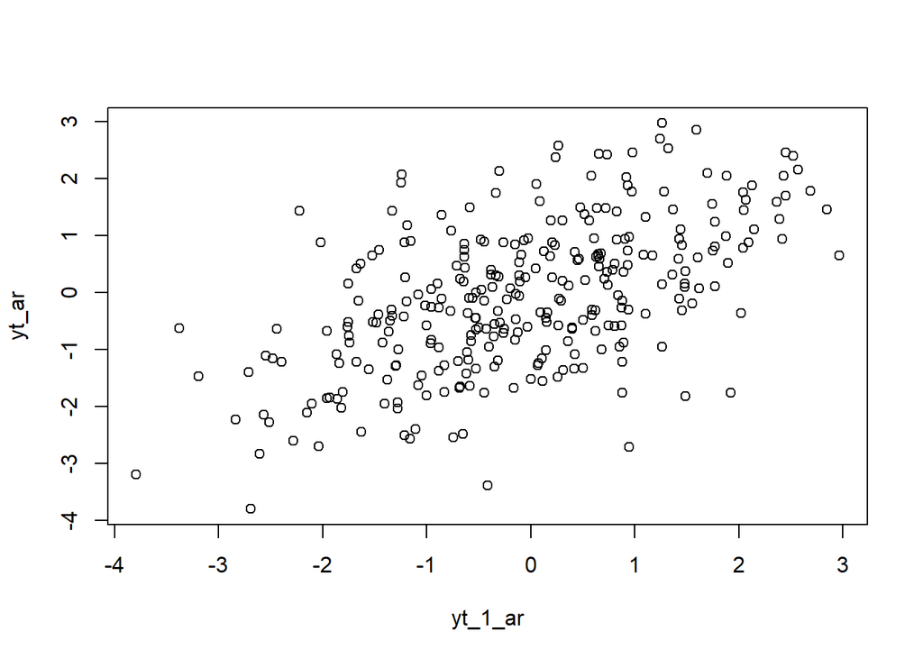

```r
plot(y=yt_ar,x=yt_1_ar)
```

```r
cor(yt_ar,yt_1_ar)
```

```
## [1] 0.5602656
```

Teoritis

$$\rho_1 = \frac{\phi_1}{1 - \phi_2}=\frac{0.5}{1-0.2}=0.625$$

### 2.6.2 Korelasi antara Yt dengan Yt-2

```r
yt_ar2 <- ar[-c(1,2)]
yt_ar2
```

```
##   [1] -0.482497456  0.921587760  2.022985277 -0.364256625  0.091038037
##   [6]  1.603298708  0.609951674  0.945895432 -2.712841705 -1.402789536
##  [11] -1.955387104 -0.677803721 -1.651791736 -0.146194512 -0.831263794
##  [16] -1.277998971 -1.932377519 -1.841080271 -1.237749826  2.071143201
##  [21]  1.622098887  0.067174653 -1.274539608 -1.001468448 -0.584854160
##  [26] -1.636007665  0.506622698 -1.328500702  1.425693515 -0.107941560
##  [31]  0.524883956  0.209931569  0.267864551  2.568203219  2.148435116
##  [36]  1.101433500  1.319257488  2.525429510  2.394362047  1.282426063
##  [41]  1.769131265  0.110644583 -1.154058688  0.896035250  0.363621993
##  [46]  0.113161687 -1.558692781 -1.348074144 -0.499303378 -0.611022463
##  [51] -1.048393358 -1.457527557  0.745679531 -0.574420301 -0.741965495
##  [56] -2.543147652 -1.106951587 -2.395378577 -1.216590203 -0.424355478
##  [61] -0.643614824  0.187415972  0.632517557  0.621147254 -0.315677472
##  [66] -1.191990704 -0.161930616 -1.673499354  0.424584000 -1.082632771
##  [71] -1.627821509 -2.441883602 -0.639076115  0.853620796 -0.952926967
```

[output cut: 45 more lines]

```r
yt_2_ar <- ar[-c(299,300)]
yt_2_ar
```

```
##   [1]  0.807249213  0.505850424 -0.482497456  0.921587760  2.022985277
##   [6] -0.364256625  0.091038037  1.603298708  0.609951674  0.945895432
##  [11] -2.712841705 -1.402789536 -1.955387104 -0.677803721 -1.651791736
##  [16] -0.146194512 -0.831263794 -1.277998971 -1.932377519 -1.841080271
##  [21] -1.237749826  2.071143201  1.622098887  0.067174653 -1.274539608
##  [26] -1.001468448 -0.584854160 -1.636007665  0.506622698 -1.328500702
##  [31]  1.425693515 -0.107941560  0.524883956  0.209931569  0.267864551
##  [36]  2.568203219  2.148435116  1.101433500  1.319257488  2.525429510
##  [41]  2.394362047  1.282426063  1.769131265  0.110644583 -1.154058688
##  [46]  0.896035250  0.363621993  0.113161687 -1.558692781 -1.348074144
##  [51] -0.499303378 -0.611022463 -1.048393358 -1.457527557  0.745679531
##  [56] -0.574420301 -0.741965495 -2.543147652 -1.106951587 -2.395378577
##  [61] -1.216590203 -0.424355478 -0.643614824  0.187415972  0.632517557
##  [66]  0.621147254 -0.315677472 -1.191990704 -0.161930616 -1.673499354
##  [71]  0.424584000 -1.082632771 -1.627821509 -2.441883602 -0.639076115
```

[output cut: 45 more lines]

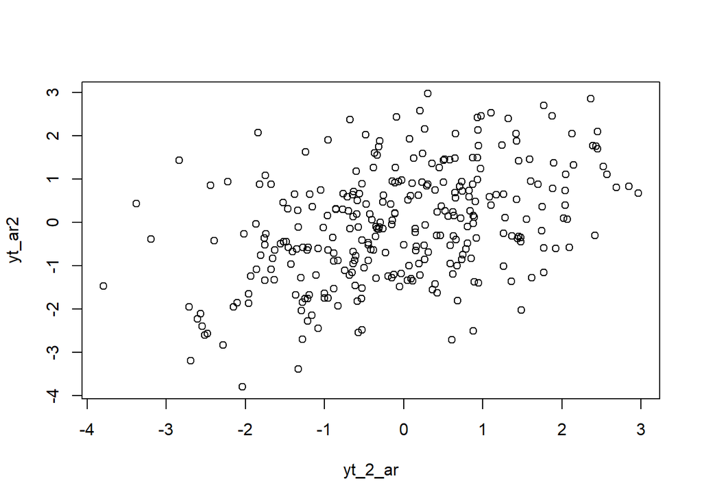

```r
plot(y=yt_ar2,x=yt_2_ar)
```

```r
cor(yt_ar2,yt_2_ar)
```

```
## [1] 0.4255846
```

Teoritis :

$$\rho_2 = \frac{\phi_1 \rho_1 + \phi_2}{1}
= \frac{\phi_1^2}{1 - \phi_2} +
\phi_2=\frac{0.5^2}{1-0.2}+0.2=0.5125$$

### 2.6.3 Korelasi antara Yt dengan Yt-3

```r
yt     <- ar[-c(1,2,3)]
yt
```

```
##   [1]  0.921587760  2.022985277 -0.364256625  0.091038037  1.603298708
##   [6]  0.609951674  0.945895432 -2.712841705 -1.402789536 -1.955387104
##  [11] -0.677803721 -1.651791736 -0.146194512 -0.831263794 -1.277998971
##  [16] -1.932377519 -1.841080271 -1.237749826  2.071143201  1.622098887
##  [21]  0.067174653 -1.274539608 -1.001468448 -0.584854160 -1.636007665
##  [26]  0.506622698 -1.328500702  1.425693515 -0.107941560  0.524883956
##  [31]  0.209931569  0.267864551  2.568203219  2.148435116  1.101433500
##  [36]  1.319257488  2.525429510  2.394362047  1.282426063  1.769131265
##  [41]  0.110644583 -1.154058688  0.896035250  0.363621993  0.113161687
##  [46] -1.558692781 -1.348074144 -0.499303378 -0.611022463 -1.048393358
##  [51] -1.457527557  0.745679531 -0.574420301 -0.741965495 -2.543147652
##  [56] -1.106951587 -2.395378577 -1.216590203 -0.424355478 -0.643614824
##  [61]  0.187415972  0.632517557  0.621147254 -0.315677472 -1.191990704
##  [66] -0.161930616 -1.673499354  0.424584000 -1.082632771 -1.627821509
##  [71] -2.441883602 -0.639076115  0.853620796 -0.952926967 -0.827877592
```

[output cut: 45 more lines]

```r
yt_3ar <- ar[-c(298,299,300)]
yt_3ar
```

```
##   [1]  0.807249213  0.505850424 -0.482497456  0.921587760  2.022985277
##   [6] -0.364256625  0.091038037  1.603298708  0.609951674  0.945895432
##  [11] -2.712841705 -1.402789536 -1.955387104 -0.677803721 -1.651791736
##  [16] -0.146194512 -0.831263794 -1.277998971 -1.932377519 -1.841080271
##  [21] -1.237749826  2.071143201  1.622098887  0.067174653 -1.274539608
##  [26] -1.001468448 -0.584854160 -1.636007665  0.506622698 -1.328500702
##  [31]  1.425693515 -0.107941560  0.524883956  0.209931569  0.267864551
##  [36]  2.568203219  2.148435116  1.101433500  1.319257488  2.525429510
##  [41]  2.394362047  1.282426063  1.769131265  0.110644583 -1.154058688
##  [46]  0.896035250  0.363621993  0.113161687 -1.558692781 -1.348074144
##  [51] -0.499303378 -0.611022463 -1.048393358 -1.457527557  0.745679531
##  [56] -0.574420301 -0.741965495 -2.543147652 -1.106951587 -2.395378577
##  [61] -1.216590203 -0.424355478 -0.643614824  0.187415972  0.632517557
##  [66]  0.621147254 -0.315677472 -1.191990704 -0.161930616 -1.673499354
##  [71]  0.424584000 -1.082632771 -1.627821509 -2.441883602 -0.639076115
```

[output cut: 45 more lines]

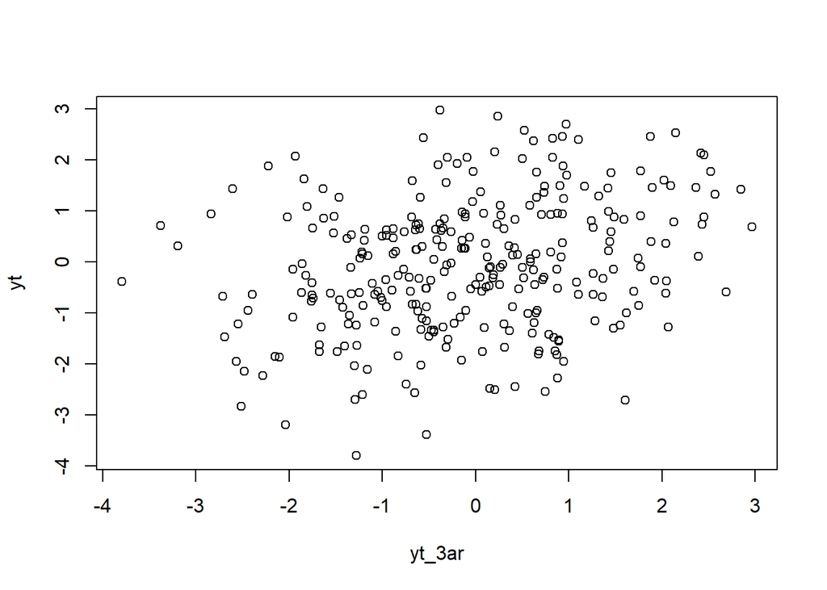

```r
plot(y=yt,x=yt_3ar)
```

```r
cor(yt,yt_3ar)
```

```
## [1] 0.2672069
```

Teoritis :

$$\rho_3 = \phi_1 \rho_2 + \phi_2 \rho_1=0.5(0.5125)+0.2(0.625)=0.38125$$

# 3 ARMA(2,2)

## 3.1 Pembangkitan Data

```r
set.seed(1015)
n <- 300
wn <- rnorm(n)
arma <- numeric(n)

for (i in 3:n) {
  arma[i] <- 0.5 * arma[i-1] + 0.2 * arma[i-2] +
             wn[i] + 0.4 * wn[i-1] + 0.6 * wn[i-2]
}

arma
```

```
##   [1]  0.00000000  0.00000000 -0.83142823 -2.93853164 -4.74981485 -4.81066193
##   [7] -4.17915037 -3.90850031 -2.76422678 -2.40102518 -1.71970399 -1.07283203
##  [13] -2.07830358 -1.28657592 -1.34536389 -1.37757039 -1.51518085 -0.54726437
##  [19] -0.61525169  0.43956883  0.99626334  1.77338968  3.32805138  4.69504223
##  [25]  3.97238840  3.21063745  1.66836192  0.20345276  1.03153529  2.10169214
##  [31]  0.99756251  1.15887678  1.42096954  1.30574882  2.15174466 -1.96859689
##  [37] -1.92045327 -4.14425697 -2.30166966 -3.09617398 -1.21361516 -1.88083320
##  [43] -1.69823382 -2.94234501 -3.38083800 -3.13361404  0.47139084  1.70790302
##  [49]  1.95869765 -0.27441230 -1.47098094 -1.75016640 -2.47083124 -0.49869350
##  [55] -2.10745671  1.19826648 -0.33476486  1.33712323  0.35512005  0.66676743
##  [61]  2.80130788  3.33643506  3.50172942  3.04889192  3.71399257  4.19608832
##  [67]  3.75542857  3.71871890  1.58775272 -0.04832210  0.50079852  0.02960088
##  [73]  0.79623163 -1.29525491 -1.90365425 -1.97374871 -1.61958830 -1.59238437
##  [79] -2.24349838 -0.46636751 -1.15066502 -0.52432590 -3.18458603 -2.56938994
##  [85] -4.36404780 -2.83891259 -2.34821871 -1.54331114 -0.32464325  0.32131505
```

[output cut: 35 more lines]

```r
set.seed(1015)
arma_sim <- arima.sim(
  list(order = c(2,0,2), ar = c(0.5, 0.2), ma = c(0.4, 0.6)),
  n = 300
)

arma_sim
```

```
## Time Series:
## Start = 1
## End = 300
## Frequency = 1
##   [1]  0.20345276  1.03153529  2.10169214  0.99756251  1.15887678  1.42096954
##   [7]  1.30574882  2.15174466 -1.96859689 -1.92045327 -4.14425697 -2.30166966
##  [13] -3.09617398 -1.21361516 -1.88083320 -1.69823382 -2.94234501 -3.38083800
##  [19] -3.13361404  0.47139084  1.70790302  1.95869765 -0.27441230 -1.47098094
##  [25] -1.75016640 -2.47083124 -0.49869350 -2.10745671  1.19826648 -0.33476486
##  [31]  1.33712323  0.35512005  0.66676743  2.80130788  3.33643506  3.50172942
##  [37]  3.04889192  3.71399257  4.19608832  3.75542857  3.71871890  1.58775272
##  [43] -0.04832210  0.50079852  0.02960088  0.79623163 -1.29525491 -1.90365425
##  [49] -1.97374871 -1.61958830 -1.59238437 -2.24349838 -0.46636751 -1.15066502
##  [55] -0.52432590 -3.18458603 -2.56938994 -4.36404780 -2.83891259 -2.34821871
##  [61] -1.54331114 -0.32464325  0.32131505  0.98660386  0.31229196 -0.94557334
```

[output cut: 39 more lines]

## 3.2 Plot Time Series

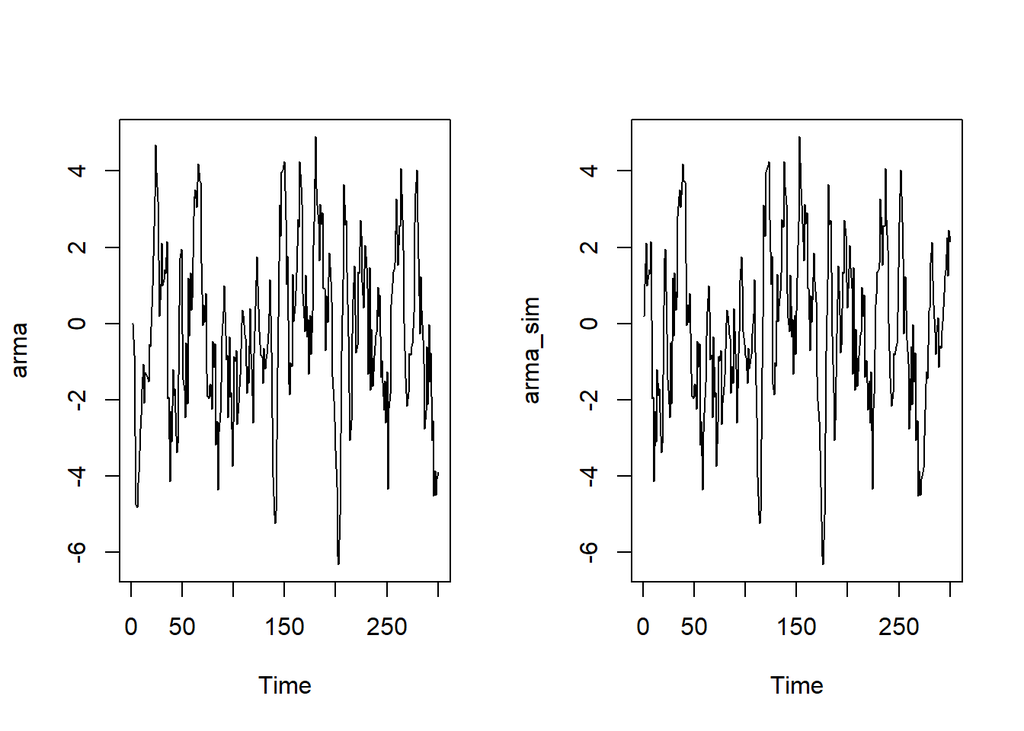

```r
par(mfrow = c(1, 2))
ts.plot(arma)
ts.plot(arma_sim)
```

Kedua plot menampilkan pola fluktuasi acak yang serupa, berosilasi di sekitar rata-rata nol tanpa adanya tren jangka panjang. Hal ini menunjukkan bahwa proses yang terbentuk bersifat stasioner, baik dalam mean maupun varians, sehingga model ARMA yang dibangun mampu merepresentasikan data dengan baik dan menghasilkan simulasi yang konsisten dengan sifat proses aslinya.

## 3.3 Plot ACF

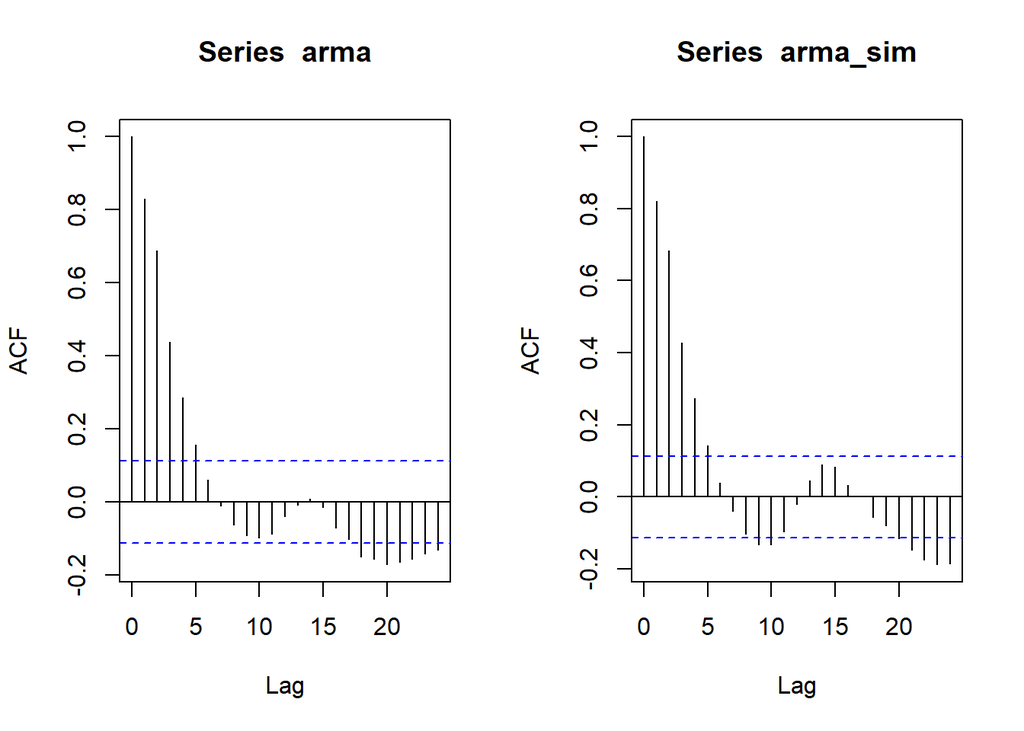

```r
par(mfrow = c(1, 2))
acf(arma)
acf(arma_sim)
```

## 3.4 Plot PACF

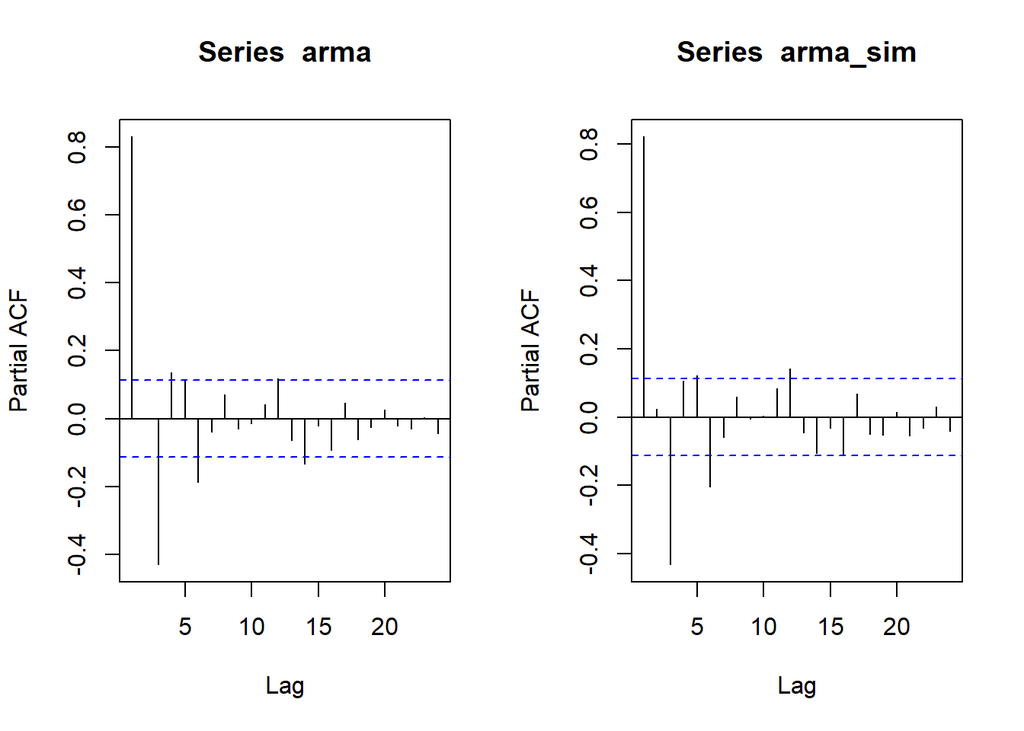

```r
par(mfrow = c(1, 2))
pacf(arma)
pacf(arma_sim)
```

## 3.5 Plot EACF

```r
TSA::eacf(arma)
```

```
## AR/MA
##   0 1 2 3 4 5 6 7 8 9 10 11 12 13
## 0 x x x x x o o o o o o  o  o  o
## 1 o x o o o o o o o o o  o  o  o
## 2 o x x x o o o o o o o  o  o  o
## 3 x x x o o o o o o o o  o  o  o
## 4 x x x x o o o o o o o  o  o  o
## 5 x x x o x x o o o o o  o  o  o
## 6 x x x x x x o o o o o  o  o  o
## 7 x x x o o x o o o o o  o  o  o
```

```r
TSA::eacf(arma_sim)
```

```
## AR/MA
##   0 1 2 3 4 5 6 7 8 9 10 11 12 13
## 0 x x x x x o o o x x o  o  o  o
## 1 o x o x o o o o o o o  o  o  x
## 2 o x o x o o o o o o o  o  o  o
## 3 x x x o o o o o o o o  o  o  o
## 4 x x x x o o o o o o o  o  o  o
## 5 x x x o x x o o o o o  o  o  o
## 6 x x x x x x o o o o o  o  o  o
## 7 x x o o o x x o o o o  o  o  o
```

## 3.6 Scatterplot Antar Lag

### 3.6.1 Korelasi antara Yt dengan Yt−1

```r
yt_arma <- arma_sim[-1]
yt_arma
```

```
##   [1]  1.03153529  2.10169214  0.99756251  1.15887678  1.42096954  1.30574882
##   [7]  2.15174466 -1.96859689 -1.92045327 -4.14425697 -2.30166966 -3.09617398
##  [13] -1.21361516 -1.88083320 -1.69823382 -2.94234501 -3.38083800 -3.13361404
##  [19]  0.47139084  1.70790302  1.95869765 -0.27441230 -1.47098094 -1.75016640
##  [25] -2.47083124 -0.49869350 -2.10745671  1.19826648 -0.33476486  1.33712323
##  [31]  0.35512005  0.66676743  2.80130788  3.33643506  3.50172942  3.04889192
##  [37]  3.71399257  4.19608832  3.75542857  3.71871890  1.58775272 -0.04832210
##  [43]  0.50079852  0.02960088  0.79623163 -1.29525491 -1.90365425 -1.97374871
##  [49] -1.61958830 -1.59238437 -2.24349838 -0.46636751 -1.15066502 -0.52432590
##  [55] -3.18458603 -2.56938994 -4.36404780 -2.83891259 -2.34821871 -1.54331114
##  [61] -0.32464325  0.32131505  0.98660386  0.31229196 -0.94557334 -0.82813338
##  [67] -2.45346602 -0.34197411 -1.91689878 -1.80612422 -3.74259187 -2.59252246
##  [73] -0.86713981 -0.99492432 -0.69687590 -2.64516974 -2.07735723 -1.66251556
##  [79] -1.34759020  0.02231128  0.34601042  0.21629715 -0.29390858 -0.38495690
##  [85] -1.83016890 -1.12725187 -1.56396089  0.40193744 -0.79086630 -1.19256528
```

[output cut: 35 more lines]

```r
yt_1_arma <- arma_sim[-300]
yt_1_arma
```

```
##   [1]  0.20345276  1.03153529  2.10169214  0.99756251  1.15887678  1.42096954
##   [7]  1.30574882  2.15174466 -1.96859689 -1.92045327 -4.14425697 -2.30166966
##  [13] -3.09617398 -1.21361516 -1.88083320 -1.69823382 -2.94234501 -3.38083800
##  [19] -3.13361404  0.47139084  1.70790302  1.95869765 -0.27441230 -1.47098094
##  [25] -1.75016640 -2.47083124 -0.49869350 -2.10745671  1.19826648 -0.33476486
##  [31]  1.33712323  0.35512005  0.66676743  2.80130788  3.33643506  3.50172942
##  [37]  3.04889192  3.71399257  4.19608832  3.75542857  3.71871890  1.58775272
##  [43] -0.04832210  0.50079852  0.02960088  0.79623163 -1.29525491 -1.90365425
##  [49] -1.97374871 -1.61958830 -1.59238437 -2.24349838 -0.46636751 -1.15066502
##  [55] -0.52432590 -3.18458603 -2.56938994 -4.36404780 -2.83891259 -2.34821871
##  [61] -1.54331114 -0.32464325  0.32131505  0.98660386  0.31229196 -0.94557334
##  [67] -0.82813338 -2.45346602 -0.34197411 -1.91689878 -1.80612422 -3.74259187
##  [73] -2.59252246 -0.86713981 -0.99492432 -0.69687590 -2.64516974 -2.07735723
##  [79] -1.66251556 -1.34759020  0.02231128  0.34601042  0.21629715 -0.29390858
##  [85] -0.38495690 -1.83016890 -1.12725187 -1.56396089  0.40193744 -0.79086630
```

[output cut: 35 more lines]

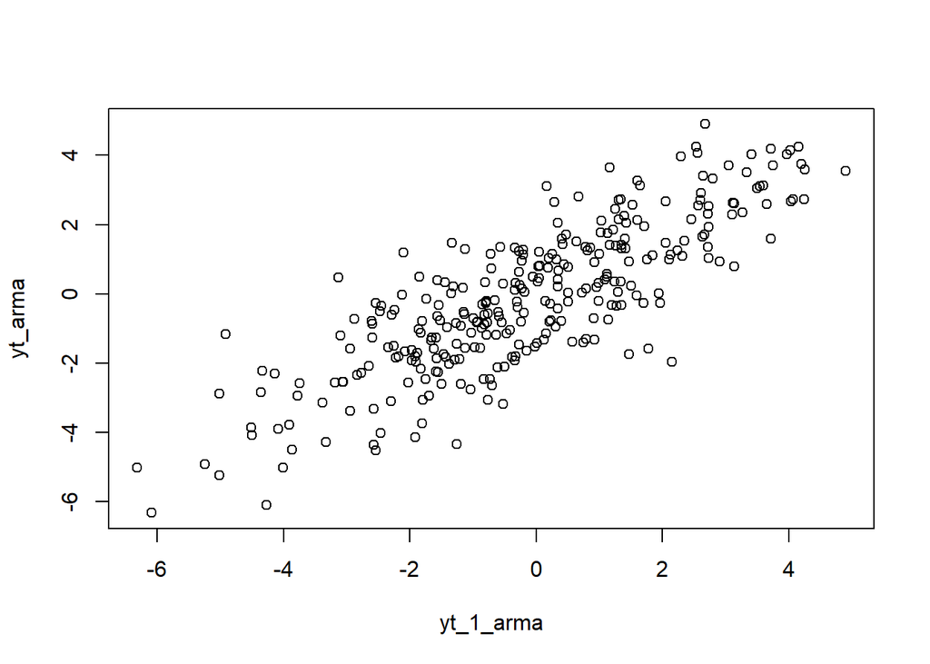

```r
plot(y=yt_arma,x=yt_1_arma)
```

```r
cor(yt_arma,yt_1_arma)
```

```
## [1] 0.8233768
```

Teoritis :

$$\gamma_0 = (1 + \theta_1^2 + \theta_2^2)\sigma^2 + \phi_1 \theta_1
\sigma^2 + \phi_2 \theta_2 \sigma^2 + \phi_1 \theta_1 \theta_2 \sigma^2$$
$$= (1 + 0.4^2 + 0.6^2)\sigma^2 + 0.5(0.4)\sigma^2 + 0.2(0.6)\sigma^2 +
0.5(0.4)(0.6)\sigma^2$$
$$= 1.96\sigma^2$$

$$\gamma_1 = (\theta_1 + \theta_1\theta_2 + \phi_1 +
\phi_1\theta_1)\sigma^2 + \phi_2\gamma_0$$
$$= (0.4 + 0.4(0.6) + 0.5 + 0.5(0.4))\sigma^2 + 0.2(1.96\sigma^2)$$
$$= 1.732\sigma^2$$

Autokorelasi

$$\rho_1 = \frac{\gamma_1}{\gamma_0} = \frac{1.732\sigma^2}{1.96\sigma^2}
\approx 0.8837$$

### 3.6.2 Korelasi antara Yt dengan Yt-2

```r
yt_arma2 <- arma_sim[-c(1,2)]
yt_arma2
```

```
##   [1]  2.10169214  0.99756251  1.15887678  1.42096954  1.30574882  2.15174466
##   [7] -1.96859689 -1.92045327 -4.14425697 -2.30166966 -3.09617398 -1.21361516
##  [13] -1.88083320 -1.69823382 -2.94234501 -3.38083800 -3.13361404  0.47139084
##  [19]  1.70790302  1.95869765 -0.27441230 -1.47098094 -1.75016640 -2.47083124
##  [25] -0.49869350 -2.10745671  1.19826648 -0.33476486  1.33712323  0.35512005
##  [31]  0.66676743  2.80130788  3.33643506  3.50172942  3.04889192  3.71399257
##  [37]  4.19608832  3.75542857  3.71871890  1.58775272 -0.04832210  0.50079852
##  [43]  0.02960088  0.79623163 -1.29525491 -1.90365425 -1.97374871 -1.61958830
##  [49] -1.59238437 -2.24349838 -0.46636751 -1.15066502 -0.52432590 -3.18458603
##  [55] -2.56938994 -4.36404780 -2.83891259 -2.34821871 -1.54331114 -0.32464325
##  [61]  0.32131505  0.98660386  0.31229196 -0.94557334 -0.82813338 -2.45346602
##  [67] -0.34197411 -1.91689878 -1.80612422 -3.74259187 -2.59252246 -0.86713981
##  [73] -0.99492432 -0.69687590 -2.64516974 -2.07735723 -1.66251556 -1.34759020
##  [79]  0.02231128  0.34601042  0.21629715 -0.29390858 -0.38495690 -1.83016890
##  [85] -1.12725187 -1.56396089  0.40193744 -0.79086630 -1.19256528 -2.60405338
```

[output cut: 35 more lines]

```r
yt_2_arma <- arma_sim[-c(299,300)]
yt_2_arma
```

```
##   [1]  0.20345276  1.03153529  2.10169214  0.99756251  1.15887678  1.42096954
##   [7]  1.30574882  2.15174466 -1.96859689 -1.92045327 -4.14425697 -2.30166966
##  [13] -3.09617398 -1.21361516 -1.88083320 -1.69823382 -2.94234501 -3.38083800
##  [19] -3.13361404  0.47139084  1.70790302  1.95869765 -0.27441230 -1.47098094
##  [25] -1.75016640 -2.47083124 -0.49869350 -2.10745671  1.19826648 -0.33476486
##  [31]  1.33712323  0.35512005  0.66676743  2.80130788  3.33643506  3.50172942
##  [37]  3.04889192  3.71399257  4.19608832  3.75542857  3.71871890  1.58775272
##  [43] -0.04832210  0.50079852  0.02960088  0.79623163 -1.29525491 -1.90365425
##  [49] -1.97374871 -1.61958830 -1.59238437 -2.24349838 -0.46636751 -1.15066502
##  [55] -0.52432590 -3.18458603 -2.56938994 -4.36404780 -2.83891259 -2.34821871
##  [61] -1.54331114 -0.32464325  0.32131505  0.98660386  0.31229196 -0.94557334
##  [67] -0.82813338 -2.45346602 -0.34197411 -1.91689878 -1.80612422 -3.74259187
##  [73] -2.59252246 -0.86713981 -0.99492432 -0.69687590 -2.64516974 -2.07735723
##  [79] -1.66251556 -1.34759020  0.02231128  0.34601042  0.21629715 -0.29390858
##  [85] -0.38495690 -1.83016890 -1.12725187 -1.56396089  0.40193744 -0.79086630
```

[output cut: 35 more lines]

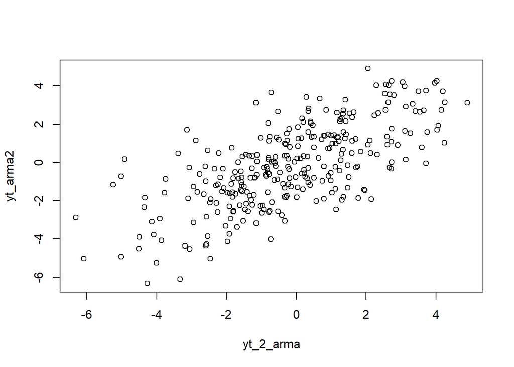

```r
plot(y=yt_arma2,x=yt_2_arma)
```

```r
cor(yt_arma2,yt_2_arma)
```

```
## [1] 0.6863971
```

### 3.6.3 Korelasi antara Yt dengan Yt-3

```r
yt_arma     <- arma_sim[-c(1,2,3)]
yt_arma
```

```
##   [1]  0.99756251  1.15887678  1.42096954  1.30574882  2.15174466 -1.96859689
##   [7] -1.92045327 -4.14425697 -2.30166966 -3.09617398 -1.21361516 -1.88083320
##  [13] -1.69823382 -2.94234501 -3.38083800 -3.13361404  0.47139084  1.70790302
##  [19]  1.95869765 -0.27441230 -1.47098094 -1.75016640 -2.47083124 -0.49869350
##  [25] -2.10745671  1.19826648 -0.33476486  1.33712323  0.35512005  0.66676743
##  [31]  2.80130788  3.33643506  3.50172942  3.04889192  3.71399257  4.19608832
##  [37]  3.75542857  3.71871890  1.58775272 -0.04832210  0.50079852  0.02960088
##  [43]  0.79623163 -1.29525491 -1.90365425 -1.97374871 -1.61958830 -1.59238437
##  [49] -2.24349838 -0.46636751 -1.15066502 -0.52432590 -3.18458603 -2.56938994
##  [55] -4.36404780 -2.83891259 -2.34821871 -1.54331114 -0.32464325  0.32131505
##  [61]  0.98660386  0.31229196 -0.94557334 -0.82813338 -2.45346602 -0.34197411
##  [67] -1.91689878 -1.80612422 -3.74259187 -2.59252246 -0.86713981 -0.99492432
##  [73] -0.69687590 -2.64516974 -2.07735723 -1.66251556 -1.34759020  0.02231128
##  [79]  0.34601042  0.21629715 -0.29390858 -0.38495690 -1.83016890 -1.12725187
##  [85] -1.56396089  0.40193744 -0.79086630 -1.19256528 -2.60405338 -0.78303331
```

[output cut: 35 more lines]

```r
yt_3arma <- arma_sim[-c(298,299,300)]
yt_3arma
```

```
##   [1]  0.20345276  1.03153529  2.10169214  0.99756251  1.15887678  1.42096954
##   [7]  1.30574882  2.15174466 -1.96859689 -1.92045327 -4.14425697 -2.30166966
##  [13] -3.09617398 -1.21361516 -1.88083320 -1.69823382 -2.94234501 -3.38083800
##  [19] -3.13361404  0.47139084  1.70790302  1.95869765 -0.27441230 -1.47098094
##  [25] -1.75016640 -2.47083124 -0.49869350 -2.10745671  1.19826648 -0.33476486
##  [31]  1.33712323  0.35512005  0.66676743  2.80130788  3.33643506  3.50172942
##  [37]  3.04889192  3.71399257  4.19608832  3.75542857  3.71871890  1.58775272
##  [43] -0.04832210  0.50079852  0.02960088  0.79623163 -1.29525491 -1.90365425
##  [49] -1.97374871 -1.61958830 -1.59238437 -2.24349838 -0.46636751 -1.15066502
##  [55] -0.52432590 -3.18458603 -2.56938994 -4.36404780 -2.83891259 -2.34821871
##  [61] -1.54331114 -0.32464325  0.32131505  0.98660386  0.31229196 -0.94557334
##  [67] -0.82813338 -2.45346602 -0.34197411 -1.91689878 -1.80612422 -3.74259187
##  [73] -2.59252246 -0.86713981 -0.99492432 -0.69687590 -2.64516974 -2.07735723
##  [79] -1.66251556 -1.34759020  0.02231128  0.34601042  0.21629715 -0.29390858
##  [85] -0.38495690 -1.83016890 -1.12725187 -1.56396089  0.40193744 -0.79086630
```

[output cut: 35 more lines]

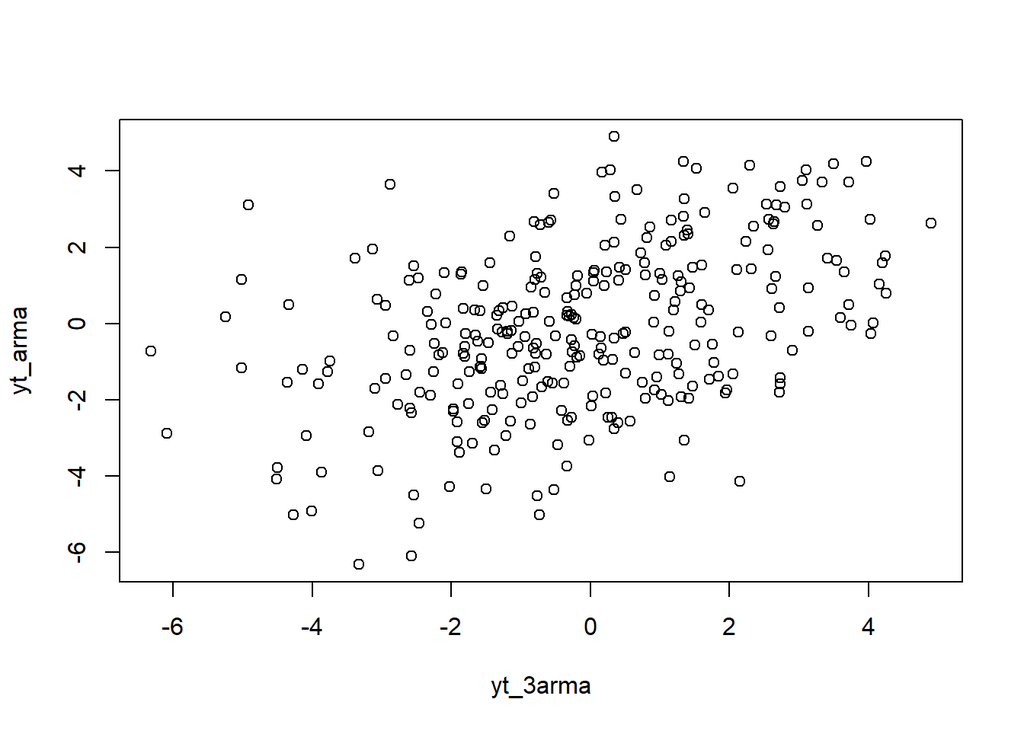

```r
plot(y=yt_arma,x=yt_3arma)
```

```r
cor(yt_arma,yt_3arma)
```

```
## [1] 0.4305791
```

Teoritis :
$$\rho_3 = \frac{\gamma_3}{\gamma_0}
= \frac{1.2754\sigma^2}{1.96\sigma^2}
\approx 0.6507$$